# Online media coverage before and after the Bundestag elections in 2017

Franziska Löw

06 Sep 2020

# 1. Introduction

## 1.1 Motivation

In recent decades, voices that criticize the role of the media in politics in general and especially in election campaigns have become louder. This criticism is fueled above all by the good performance of right-wing populist parties throughout Europe. The underlying argument is that mass media lends legitimacy to the populist right by giving attention to these parties and their issues (supply-side explanation for the success of right-wing populist parties).

In Germany, the debate has culminated after the 2017 federal elections, with the AfD being elected to the Bundestag for the first time.

Apart from the lack of evidence of a causal relationship between the frequency of reporting and AfD survey results, the following questions arise:

**Did media report biased during the election campaign? Have AfD campaigns been increasingly present in the media coverage?**

- It has been argued that the mass media can play a significant role in promoting the success of the populist right.
  - The mass media are argued to provide legitimacy to the populist right by giving attention to these parties and their issues (Sheets et al. 2016)
  - A higher dose of exposure to populist news coverage enhances both prior agreement and disagreement with populism.
  - Issue ownership: By repeatedly paying attention to specific issues, media raise issue-related public concerns, subsequently increasing citizens’ likelihood to cast their vote on the basis of these salient issues (Damstra, 2019).

**Is there a significant difference to the the time period after election?**

- News media are often accused of partisanship and biased reporting, especially during election campaigns (Eberl, 2018)
  - Content analyses in Europe as well as in the United States show that news outlets often differ in their coverage of parties and candidates during election campaigns (Eberl, 2018)

**Theoretical explanation for the disproportionate media coverage of AfD issues.**

- There are structural similarities between the “logic of right-wing populism” and the attention strategy of the mass media. (Gäbler 2017)
  - Populist key messages by political and media actors in news articles provoke more reader comments (Blassnig, 2019). Populist messages often co-occur witha negative, emotionalized, or dramatized communication style (Ernst, Blassnig, Engesser,Büchel, & Esser,2019). Therefore, it can be assumed that the occurrence of populist key messages may have a positive impact on the amount of comments an article receives.
  - Populist communication has been described as highly compatible with media logic and attributed with a high news value (Mazzoleni, 2008).
  - The media primarily focus on news factors, i.e. the factors that turn an event into news worth reporting. In the case of AfD, a number of news factors are very high: conflict, drama, negativity, surprise, proximity. Finally, the AfD uses the mechanisms of the media attention economy like no other party.
  - Media logic (Takens et al. 2013): Media logic refers to ‘the news values and the storytelling techniques the media make use of to take advantage of their own medium and its format, and to be competitive in the ongoing struggle to capture people’s attention’ (Strömbäck, 2008:233).

## 1.2 Empirical strategy

I develop and apply a machine learning approach based on structural topic modeling in combination with cosine similarity and a regression discontinuity framework in order to identify similarities between topics addressed in press releases and online news articles of different media sources before and after the Bundestag elections that took place the 24th of Sep 2017.

### 1.2.2 Regression model

Use topic similarity as the external variable in a regression model

3. Estimate an **OLS model** for each media outlet $i$

$$\text{CosineSimilarity}_{i}=\beta_0+\beta_nDn_{j}+\epsilon_i$$
where the $D2_{j}, D3_{j}, ... ,Dn_{j}$ represent dummy variables for a political party $j$

4. Estimate a **regression discontinuity model** for each media outlet $i$

$$\text{CosineSimilarity}_{i}=\beta_0+\beta_1T_i+\beta_nDn_{j}+\beta_{n+n}T_iDn_{j}+\epsilon_i$$

$$T_i = 1 \text{ if date } >= \text{election date} \\
T_i = 0 \text{ if date } < \text{election date}$$
## 1.3 Results

1. **OLS model** (without treatment effect): Considering the whole period, is there a difference between topic similarity of a newspaper and AfD compared to the topic similarity of that newspaper and all other parties?

-> Yes, looking at the whole time, nearly all newspapers have a significant higher topic similarity with the AfD press releases compared to the other parties.

2. **Regression discont. model** (OLS with treatment effect): Does the topic similarity of a newspaper and the AfD significantly change after the election date?

-> The model shows that for 4 newspapers (Die Welt, stern.de, FOCUS Online, Bild.de), topic similarity with AfD was significantly lower AFTER the election.

The results indicate that - prior to the election - all newspapers (except for Handelsblatt) selected topics more similar to the AfD compared to the other parties. The election significantly changed the topic selection especially for Bild.de as the topic similarity increased significantly for nearly all parties (compared to AfD).

# 2. Data

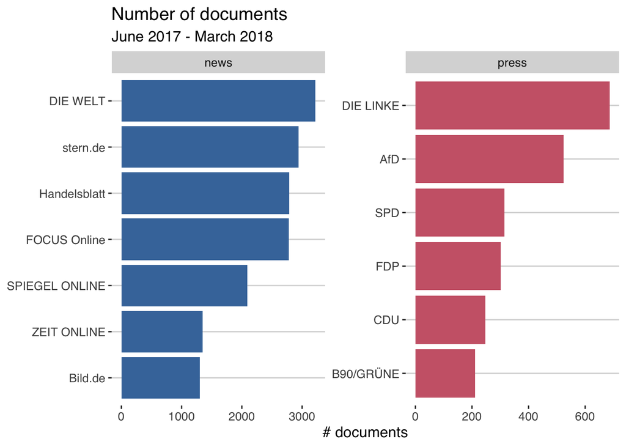

```r
model_df %>%
  group_by(type, source) %>%
  tally() %>%
  ggplot(aes(reorder(source, n),n, fill = type)) +
  geom_col(show.legend = F) +
  ggthemes::theme_hc() +
  ggthemes::scale_fill_ptol() +
  coord_flip() +
  labs(y="# documents", x=NULL, title = "Number of documents", subtitle = "June 2017 - March 2018") +
  facet_wrap(~type, scales = "free")
```

# 3. Structural topic model

To discover the latent topics in the corpus of press releases and news articles, a structural topic modeling (STM) developed by [Roberts (2016)](https://scholar.princeton.edu/sites/default/files/bstewart/files/a_model_of_text_for_experimentation_in_the_social_sciences.pdf) is applied. The STM is an unsupervised machine learning approach that models topics as multinomial distributions of words and documents as multinomial distributions of topics, allowing to incorporate external variables that effect both, topical content and topical prevalence.

## 3.1 Results of the STM

[figure not shown]

To explore the words associated with each topic we use the words with the highest probability in each topic. As we included the source type (press release or news paper) as a control for the topical content (the word distribution of each topic), we have two different labels for each topic.

Each document has a probability distribution over all topics, e.g.

```r
# select a random document
#sample_doc <- sample(unique(theta$doc_index),1)
sample_doc <- 1202

sample <- theta %>% filter(doc_index == sample_doc)
title <- model_df %>% filter(doc_index == sample_doc) %>% select(title, source)
title
```

| title | source |
| --- | --- |
| Glyphosat-Streit vergiftet GroKo-Verhandlungen: Was wusste Merkel? | Bild.de |

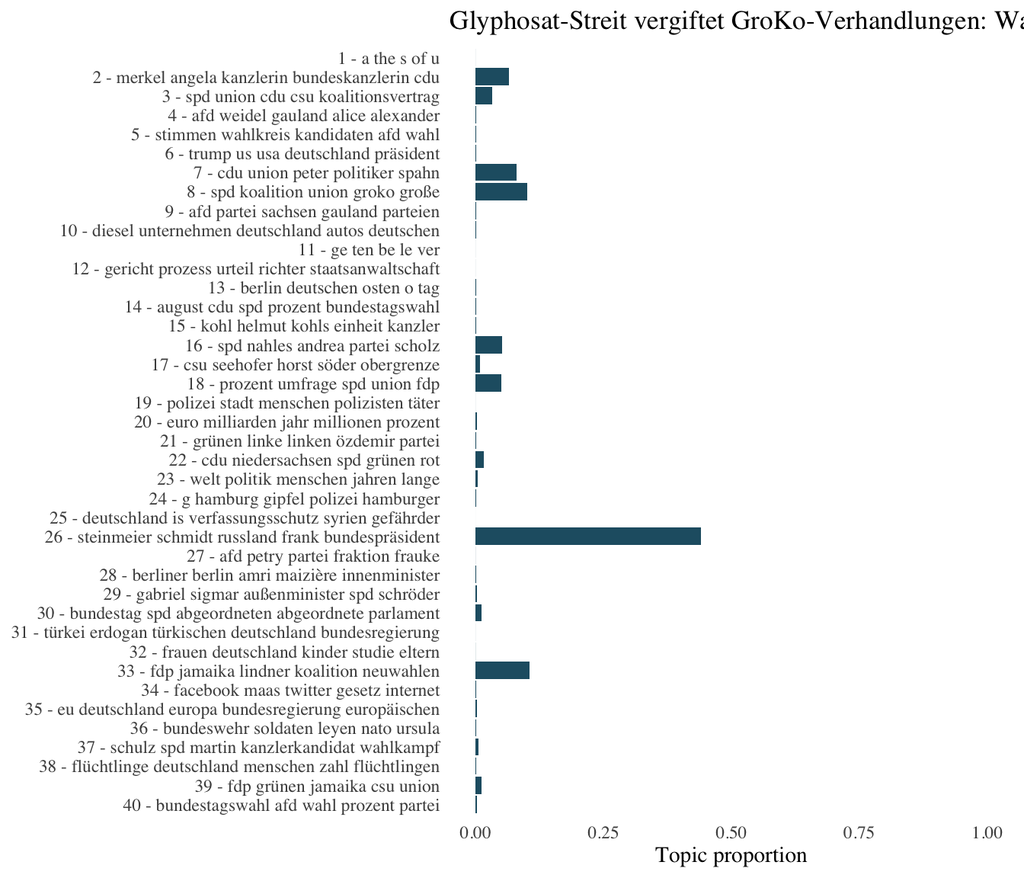

```r
sample %>%
  ggplot(aes(reorder(topic_label,desc(topic)), theta)) +
  geom_col(fill='#235d72') +
  coord_flip() +
  ylim(c(0,1)) +
  theme_tufte(ticks = FALSE) +
  labs(x = NULL, y = "Topic proportion", title = paste0(title$title," (",title$source,")"))
```

# 3. Cosine similarity

Cosine similarity is built on the geometric definition of the dot product of two vectors. It is a measure for the distance between two vectors and is defined between zero and one; values towards 1 indicate similarity.

$$\text{cosine similarity} = \text{cos}(\theta)=\frac{a*b}{||a|| ||b||}$$

As topic proportions per news article / press release are vectors of the same length, the cosine similarity allows a comparison of the topic distribution between two documents. Applications of cosine similarity to compare of topic model outcomes: [Ramage et al. 2010](https://citeseerx.ist.psu.edu/viewdoc/download?doi=10.1.1.224.8995&rep=rep1&type=pdf), [Rehs 2020](https://link.springer.com/article/10.1007/s11192-020-03640-0#Sec8)

```r
calc_cos_sim <- function(doc_code,
                         gamma_mat = gamma) {
  # find the doc
  doc_col_index <- which(colnames(gamma_mat) == as.character(doc_code))
  # get the week of the doc
  date_target <- filter(model_df, doc_index == doc_code)$date
  # get all doc_codes +/- 4 days
  date_seq <- seq(from=date_target-4,by="day",length.out = 9)
  doc_code_pairs <- filter(model_df, year_week %in% date_seq)$doc_index
  # calculate cosine similarity for each document based on gamma
  # apply(..., 2) iterates over the columns of a matrix
  cos_sims <- apply(gamma_mat[, doc_code_pairs], 2,
    FUN = function(y) cosine_sim(gamma_mat[, doc_col_index], y)
  )

  # return results as data frame
  data_frame(
    doc_code1 = doc_code,
    doc_code2 = as.numeric(names(cos_sims)),
    cos_sim = cos_sims
  ) %>%
    filter(doc_code2 != doc_code) # remove self reference
}
```

Calculate the cosine similarity for our sample document and all other documents and display the top 5 documents (the 5 documents most similar).

```r
#sample_doc <- sample(model_df$doc_index,1)
sample_doc <- 1202
title <- model_df %>% filter(doc_index == sample_doc) %>% select(title, source)
title
```

| title | source |
| --- | --- |
| Glyphosat-Streit vergiftet GroKo-Verhandlungen: Was wusste Merkel? | Bild.de |

```r
#sample_doc <- 1202

calc_cos_sim(sample_doc) %>%
  mutate(doc_index = doc_code2) %>%
  left_join(.,
    model_df %>%
      select(title, source, doc_index, type),
    by = "doc_index"
  ) %>%
  filter(type == "press") %>%
  arrange(desc(cos_sim)) %>%
  top_n(5, cos_sim) %>%
  select(title, source, cos_sim)
```

| title | source | cos_sim |
| --- | --- | --- |
| Weidel/Protschka: Glyphosat-Verlängerung ist ein Skandal | AfD | 0.8039572 |
| André Poggenburg: Glyphosat – Keine Zulassung ohne Klärung der wirklichen Schädlichkeit | AfD | 0.7821429 |
| Verantwortung für Tierwohl endet nicht an der Grenze | SPD | 0.6481036 |
| Dokumente aus dem EU-Vermittlungsausschuss zeigen: Glyphosat-Beschluss ist ein einziges Trauerspiel | DIE LINKE | 0.5568073 |
| Fakten müssen für Zulassung von Pflanzenschutzmitteln maßgeblich sein | FDP | 0.4740893 |

Finally, the function will be applied to all documents.

```r
run_cos_sim_loop <- function(target) {
  small_df <- model_df %>% filter(source == target)
  doc_indices <- small_df$doc_index

  print(paste("Number of documents:", length(doc_indices)))

  rm(cosine_distances)
  i <- 1
  for (x in doc_indices) {
    print(i)
    temp <- calc_cos_sim(x, gamma)

    # append the results to a data frame
    cosine_distances <- if (!exists("cosine_distances")) temp else rbind(cosine_distances, temp)

    i <- i + 1
  }

  cosine_distances
}
```

# 4. Estimate Model

```r
library(broom)
library(magrittr)
library(tidyverse)
rm(list = ls())

load("../output/models/model40_weekly_source.Rda")
election_date <- as.Date("24Sep2017", "%d%b%Y")

model_df <- model_df %>%
  dplyr::mutate(
    doc_index = as.numeric(rownames(.)),
    election_dummy = as.factor(ifelse(date <= election_date, "pre", "post")),
    year_week = lubridate::floor_date(date, "1 week")
  )
```

```r
df_prep <- function(cosine_df) {
  cosine_df %>%
    left_join(., model_df %>%
      transmute(
        doc_code1 = doc_index,
        source1 = source, type1 = type,
        date1 = date
      ),
    by = "doc_code1"
    ) %>%
    left_join(., model_df %>%
      transmute(
        doc_code2 = doc_index,
        source2 = source, type2 = type,
        date2 = date
      ),
    by = "doc_code2"
    ) %>%
    group_by(date1, source2, type2) %>%
    summarise(cos_sim = mean(cos_sim, na.rm = TRUE)) %>%
    ungroup() %>%
    mutate(election_dummy = as.factor(ifelse(date1 <= election_date, "pre", "post")))
}
```

## 4.1. OLS dummy

$$\text{CosineSimilarity}_{i}=\beta_0+\beta_nDn_{j}+\epsilon_i$$

where the $D2_{j}, D3_{j}, ... ,Dn_{j}$ represent dummy variables for a political party $j$

```r
calc_dumm <- function(dataframe) {
  temp_df <- dataframe %>%
    filter(type2 == "press")

  model_outcome <- temp_df %$%
    lm(log(cos_sim) ~ source2)
}
```

```r
# ----------------------------
target_source <- "DIE WELT"
load(paste0("../output/cosine_dist_", target_source, ".Rda"))
cosine_distances_df <- df_prep(welt)
welt_model <- calc_dumm(cosine_distances_df)

target_source <- "stern.de"
load(paste0("../output/cosine_dist_", target_source, ".Rda"))
cosine_distances_df <- df_prep(stern)
stern_model <- calc_dumm(cosine_distances_df)

target_source <- "ZEIT ONLINE"
load(paste0("../output/cosine_dist_", target_source, ".Rda"))
cosine_distances_df <- df_prep(zeit)
zeit_model <- calc_dumm(cosine_distances_df)

target_source <- "Handelsblatt"
load(paste0("../output/cosine_dist_", target_source, ".Rda"))
cosine_distances_df <- df_prep(handelsblatt)
handelsblatt_model <- calc_dumm(cosine_distances_df)

target_source <- "FOCUS Online"
load(paste0("../output/cosine_dist_", target_source, ".Rda"))
cosine_distances_df <- df_prep(focus)
focus_model <- calc_dumm(cosine_distances_df)

target_source <- "Bild.de"
load(paste0("../output/cosine_dist_", target_source, ".Rda"))
cosine_distances_df <- df_prep(bild)
bild_model <- calc_dumm(cosine_distances_df)

target_source <- "SPIEGEL ONLINE"
load(paste0("../output/cosine_dist_", target_source, ".Rda"))
cosine_distances_df <- df_prep(spiegel)
spiegel_model <- calc_dumm(cosine_distances_df)
```

```r
stargazer::stargazer(welt_model, stern_model, zeit_model, handelsblatt_model,
                     focus_model, bild_model, spiegel_model,
                     column.labels = c("DIE WELT", "stern.de", "ZEIT ONLINE",
                                       "Handelsblatt", "FOCUS Online", "Bild.de",
                                       "SPIEGEL ONLINE"),
                     dep.var.labels = paste0("Cosine similarity of topic distribution"),
                     single.row = TRUE,
                     #font.size = "tiny",
                     type = "text")
```

```
##
## ============================================================================================================================================================================================
##                                                                                               Dependent variable:
##                     ------------------------------------------------------------------------------------------------------------------------------------------------------------------------
##                                                                                     Cosine similarity of topic distribution
##                             DIE WELT                stern.de               ZEIT ONLINE           Handelsblatt           FOCUS Online               Bild.de               SPIEGEL ONLINE
##                               (1)                      (2)                     (3)                   (4)                    (5)                      (6)                      (7)
## --------------------------------------------------------------------------------------------------------------------------------------------------------------------------------------------
## source2B90/GRÜNE       -0.250*** (0.035)        -0.231*** (0.045)       -0.233*** (0.052)       0.046 (0.047)        -0.329*** (0.037)        -0.343*** (0.052)        -0.204*** (0.043)
## source2CDU             -0.257*** (0.033)        -0.189*** (0.043)       -0.233*** (0.049)       0.035 (0.044)        -0.304*** (0.035)        -0.280*** (0.049)        -0.233*** (0.040)
## source2DIE LINKE       -0.316*** (0.033)        -0.152*** (0.043)       -0.251*** (0.049)       0.038 (0.044)        -0.342*** (0.035)        -0.318*** (0.049)        -0.223*** (0.040)
## source2FDP             -0.277*** (0.033)        -0.209*** (0.043)       -0.193*** (0.049)       0.057 (0.044)        -0.348*** (0.035)        -0.314*** (0.049)        -0.232*** (0.040)
## source2SPD             -0.312*** (0.034)        -0.185*** (0.043)       -0.271*** (0.050)       0.017 (0.045)        -0.365*** (0.036)        -0.306*** (0.050)        -0.289*** (0.041)
## Constant               -1.760*** (0.023)        -1.998*** (0.030)       -1.750*** (0.035)     -1.856*** (0.031)      -1.825*** (0.025)        -1.749*** (0.035)        -1.882*** (0.029)
## --------------------------------------------------------------------------------------------------------------------------------------------------------------------------------------------
## Observations                 1,382                    1,388                   1,418                 1,208                  1,442                    1,336                    1,438
## R2                           0.085                    0.026                   0.028                 0.002                  0.098                    0.049                    0.041
## Adjusted R2                  0.081                    0.022                   0.025                 -0.002                 0.095                    0.045                    0.038
## Residual Std. Error    0.363 (df = 1376)        0.468 (df = 1382)       0.546 (df = 1412)     0.454 (df = 1202)      0.393 (df = 1436)        0.528 (df = 1330)        0.450 (df = 1432)
## F Statistic         25.404*** (df = 5; 1376) 7.377*** (df = 5; 1382) 8.142*** (df = 5; 1412) 0.425 (df = 5; 1202) 31.242*** (df = 5; 1436) 13.609*** (df = 5; 1330) 12.296*** (df = 5; 1432)
## ============================================================================================================================================================================================
## Note:                                                                                                                                                            *p<0.1; **p<0.05; ***p<0.01
```

#### Interpretation:

When $D$ swichtes from from 0 to 1, the % impact of $D$ on $Y$ is: $100(exp(\beta)-1)$

**DIE WELT**

$100(exp(-0.25)-1) = -22\%$

Compared to AfD, the similarity of topics of DIE WELT and B90/G is 22% lower.

## 4.2. Regression discontinuity model

The idea of regression regression discontinuity design is to use observations with a $W_i$ close to $c$ for the estimation of $\beta_1$. $\beta_1$ is the average treatment effect for observations with $W_i = c$ which is assumed to be a good approximation to the overall treatment effect. In other words, $\beta_1$ gives us the average change of news coverage of media outlet $i$ after the election day. Since interaction terms $T_iDn_{j}$ are included, we can estimate the treatment effect for each party.

Calculate a regression discontinuity model for each newspaper $i$.

$$\text{CosineSimilarity}_{i}=\beta_0+\beta_1T_i+\beta_2W_{centered}+\beta_nDn_{j}+\beta_{n+n}T_iDn_{j}+\epsilon_i$$

where $D2_{j}, D3_{j}, ... ,Dn_{j}$ represent dummy variables for a political party $j$ and $W_{centered} = $ date - election day.

$$T_i = 1 \text{ if date } >= \text{election date} \\
T_i = 0 \text{ if date } < \text{election date}$$

so that the receipt of treatment $T_i$ is determined by the threshold $c$ (election day) of the continuous variable $W_i$ (date), the so called running variable.

```r
plot_data <- function(dataframe) {
  cosine_distances_df %>%
    filter(type2 == "press") %>%
    ggplot(aes(date1, cos_sim, color = election_dummy)) +
    geom_point(show.legend = F) +
    geom_vline(xintercept = election_date) +
    ggthemes::theme_clean() +
    labs(y = "Cosine similarity of topic distribution", x = "") +
    facet_wrap(~source2)
}
```

```r
calc_rd_dummy<- function(dataframe, target_source) {
  temp_df <- dataframe %>%
    filter(type2 == "press") %>%
    mutate(
      X_centered = I(date1 - election_date),
      treatedTRUE = ifelse(date1 >= election_date, 1, 0))

  model_outcome <- temp_df %$%
    lm(log(cos_sim) ~ treatedTRUE + source2 + X_centered)
}

calc_rd_dummy_interaction <- function(dataframe, target_source) {
  temp_df <- dataframe %>%
    filter(type2 == "press") %>%
    mutate(
      X_centered = I(date1 - election_date),
      treatedTRUE = ifelse(date1 >= election_date, 1, 0))

  model_outcome <- temp_df %$%
    lm(log(cos_sim) ~ treatedTRUE * source2 + X_centered)
}
```

```r
target_source <- "DIE WELT"
#load(paste0("../output/cosine_dist_", target_source, ".Rda"))
cosine_distances_df <- df_prep(welt)
welt_model1 <- calc_rd_dummy(cosine_distances_df, target_source)
welt_model2 <- calc_rd_dummy_interaction(cosine_distances_df, target_source)

target_source <- "stern.de"
#load(paste0("../output/cosine_dist_", target_source, ".Rda"))
cosine_distances_df <- df_prep(stern)
stern_model1 <- calc_rd_dummy(cosine_distances_df, target_source)
stern_model2 <- calc_rd_dummy_interaction(cosine_distances_df, target_source)

target_source <- "ZEIT ONLINE"
#load(paste0("../output/cosine_dist_", target_source, ".Rda"))
cosine_distances_df <- df_prep(zeit)
zeit_model1 <- calc_rd_dummy(cosine_distances_df, target_source)
zeit_model2 <- calc_rd_dummy_interaction(cosine_distances_df, target_source)

target_source <- "Handelsblatt"
#load(paste0("../output/cosine_dist_", target_source, ".Rda"))
cosine_distances_df <- df_prep(handelsblatt)
handelsblatt_model1 <- calc_rd_dummy(cosine_distances_df, target_source)
handelsblatt_model2 <- calc_rd_dummy_interaction(cosine_distances_df, target_source)

target_source <- "FOCUS Online"
#load(paste0("../output/cosine_dist_", target_source, ".Rda"))
cosine_distances_df <- df_prep(focus)
focus_model1 <- calc_rd_dummy(cosine_distances_df, target_source)
focus_model2 <- calc_rd_dummy_interaction(cosine_distances_df, target_source)

target_source <- "Bild.de"
#load(paste0("../output/cosine_dist_", target_source, ".Rda"))
cosine_distances_df <- df_prep(bild)
bild_model1 <- calc_rd_dummy(cosine_distances_df, target_source)
bild_model2 <- calc_rd_dummy_interaction(cosine_distances_df, target_source)

target_source <- "SPIEGEL ONLINE"
#load(paste0("../output/cosine_dist_", target_source, ".Rda"))
cosine_distances_df <- df_prep(spiegel)
spiegel_model1 <- calc_rd_dummy(cosine_distances_df, target_source)
spiegel_model2 <- calc_rd_dummy_interaction(cosine_distances_df, target_source)
```

### 4.1.1. Without interaction terms

$$\text{CosineSimilarity}_{i}=\beta_0+\beta_1T_i+\beta_nDn_{j}+\epsilon_i$$

```r
stargazer::stargazer(welt_model1, stern_model1, zeit_model1, handelsblatt_model1, focus_model1, bild_model1, spiegel_model1,
                     column.labels = c("DIE WELT", "stern.de", "ZEIT ONLINE", "Handelsblatt", "FOCUS Online", "Bild.de", "SPIEGEL ONLINE"),
                     dep.var.labels = paste0("Cosine similarity of topic distribution"),
                     single.row = TRUE,
                     #font.size = "tiny",
                     type = "text")
```

```
##
## ============================================================================================================================================================================================
##                                                                                               Dependent variable:
##                     ------------------------------------------------------------------------------------------------------------------------------------------------------------------------
##                                                                                     Cosine similarity of topic distribution
##                             DIE WELT                stern.de               ZEIT ONLINE            Handelsblatt           FOCUS Online               Bild.de              SPIEGEL ONLINE
##                               (1)                      (2)                     (3)                    (4)                    (5)                      (6)                      (7)
## --------------------------------------------------------------------------------------------------------------------------------------------------------------------------------------------
## treated                -0.115*** (0.040)        -0.177*** (0.051)       -0.154*** (0.055)      -0.158*** (0.052)        -0.061 (0.041)           0.015 (0.055)            0.012 (0.046)
## source2B90/GRÜNE       -0.261*** (0.035)        -0.236*** (0.045)       -0.254*** (0.051)        0.038 (0.047)        -0.332*** (0.037)        -0.338*** (0.052)        -0.202*** (0.043)
## source2CDU             -0.257*** (0.033)        -0.189*** (0.042)       -0.233*** (0.048)        0.035 (0.044)        -0.304*** (0.035)        -0.280*** (0.049)        -0.233*** (0.040)
## source2DIE LINKE       -0.316*** (0.033)        -0.152*** (0.042)       -0.251*** (0.048)        0.038 (0.044)        -0.342*** (0.035)        -0.318*** (0.049)        -0.223*** (0.040)
## source2FDP             -0.277*** (0.033)        -0.209*** (0.042)       -0.193*** (0.048)        0.057 (0.044)        -0.348*** (0.035)        -0.314*** (0.049)        -0.232*** (0.040)
## source2SPD             -0.315*** (0.033)        -0.182*** (0.043)       -0.277*** (0.049)        0.017 (0.045)        -0.365*** (0.036)        -0.304*** (0.049)        -0.288*** (0.041)
## X_centered              0.0001 (0.0003)         0.002*** (0.0003)        -0.001* (0.0004)      0.001*** (0.0003)       0.0004 (0.0003)          0.0005 (0.0004)         -0.00001 (0.0003)
## Constant               -1.700*** (0.030)        -1.923*** (0.038)       -1.657*** (0.043)      -1.782*** (0.040)      -1.796*** (0.032)        -1.765*** (0.044)        -1.888*** (0.036)
## --------------------------------------------------------------------------------------------------------------------------------------------------------------------------------------------
## Observations                 1,382                    1,388                   1,418                  1,208                  1,442                    1,336                    1,438
## R2                           0.102                    0.043                   0.078                  0.010                  0.100                    0.055                    0.041
## Adjusted R2                  0.098                    0.038                   0.074                  0.004                  0.095                    0.050                    0.037
## Residual Std. Error    0.360 (df = 1374)        0.464 (df = 1380)       0.532 (df = 1410)      0.453 (df = 1200)      0.393 (df = 1434)        0.527 (df = 1328)        0.450 (df = 1430)
## F Statistic         22.396*** (df = 7; 1374) 8.892*** (df = 7; 1380) 17.105*** (df = 7; 1410) 1.714 (df = 7; 1200) 22.641*** (df = 7; 1434) 11.030*** (df = 7; 1328) 8.804*** (df = 7; 1430)
## ============================================================================================================================================================================================
## Note:                                                                                                                                                            *p<0.1; **p<0.05; ***p<0.01
```

#### Interpretation:

**DIE WELT**

- Treatment effect: After the election, cosine similarity of news coverage drops by ~10,8% on average.
- Dummy variables: Compared to AfD, news coverage with all other parties is less similar

**stern.de**

- Treatment effect: After the election, cosine similarity of news coverage drops by 16,2% on average.
- Dummies: Compared to AfD, news coverage with all other parties is less similar

**Handelsblatt**

- Treatment effect: After the election, cosine similarity of news coverage drops by 14,6% on average.
- Dummies: No significant difference

### 4.1.2. With interaction terms

$$\text{CosineSimilarity}_{i}=\beta_0+\beta_1T_i+\beta_2Dn_{j}+\beta_3T_iDn_{j}+\epsilon_i$$

The interaction term $T_i*Dn$ means that the slope can vary on either side of the treatment threshold for each party.

- The coefficient $\beta_1$ is how the intercept jumps (the RDD effect)
- $\beta_3$ is how the slope changes for each party

```r
stargazer::stargazer(welt_model2, stern_model2, zeit_model2, handelsblatt_model2, focus_model2, bild_model2, spiegel_model2,
                     column.labels = c("DIE WELT", "stern.de", "ZEIT ONLINE", "Handelsblatt", "FOCUS Online", "Bild.de", "SPIEGEL ONLINE"),
                     dep.var.labels = paste0("Cosine similarity of topic distribution"),
                     single.row = TRUE,
                     #font.size = "tiny",
                     type = "text")
```

```
##
## ============================================================================================================================================================================================================
##                                                                                                            Dependent variable:
##                              -------------------------------------------------------------------------------------------------------------------------------------------------------------------------------
##                                                                                                  Cosine similarity of topic distribution
##                                      DIE WELT                  stern.de                ZEIT ONLINE             Handelsblatt            FOCUS Online                Bild.de               SPIEGEL ONLINE
##                                         (1)                      (2)                       (3)                     (4)                      (5)                      (6)                      (7)
## ------------------------------------------------------------------------------------------------------------------------------------------------------------------------------------------------------------
## treated                          -0.159*** (0.058)         -0.186** (0.075)          -0.123 (0.083)           -0.098 (0.076)          -0.118* (0.061)          -0.173** (0.084)          0.024 (0.069)
## source2B90/GRÜNE                 -0.310*** (0.048)        -0.258*** (0.062)         -0.233*** (0.072)         0.087 (0.062)          -0.399*** (0.052)        -0.498*** (0.075)        -0.261*** (0.060)
## source2CDU                       -0.258*** (0.048)        -0.166*** (0.062)         -0.209*** (0.071)         0.110* (0.062)         -0.298*** (0.052)        -0.365*** (0.075)        -0.191*** (0.059)
## source2DIE LINKE                 -0.338*** (0.048)         -0.150** (0.062)         -0.214*** (0.071)         0.072 (0.062)          -0.359*** (0.052)        -0.448*** (0.075)        -0.163*** (0.059)
## source2FDP                       -0.334*** (0.048)        -0.265*** (0.062)         -0.225*** (0.071)         0.032 (0.062)          -0.437*** (0.052)        -0.473*** (0.075)        -0.278*** (0.059)
## source2SPD                       -0.335*** (0.048)        -0.168*** (0.062)         -0.225*** (0.071)         0.069 (0.062)          -0.393*** (0.052)        -0.434*** (0.075)        -0.266*** (0.059)
## X_centered                        0.0001 (0.0003)         0.002*** (0.0003)         -0.001* (0.0004)        0.001*** (0.0003)         0.0003 (0.0003)          0.0005 (0.0004)         -0.00005 (0.0003)
## treatedTRUE:source2B90/GRÜNE       0.105 (0.070)            0.049 (0.090)            -0.039 (0.102)           -0.114 (0.096)          0.138* (0.075)           0.294*** (0.104)          0.133 (0.085)
## treatedTRUE:source2CDU             0.001 (0.066)            -0.045 (0.085)           -0.044 (0.096)          -0.151* (0.088)          -0.010 (0.070)            0.148 (0.099)            -0.078 (0.081)
## treatedTRUE:source2DIE LINKE       0.041 (0.066)            -0.005 (0.085)           -0.069 (0.096)           -0.069 (0.088)           0.031 (0.070)           0.225** (0.099)           -0.112 (0.081)
## treatedTRUE:source2FDP             0.107 (0.066)            0.107 (0.085)             0.060 (0.096)           0.050 (0.088)           0.163** (0.070)          0.275*** (0.099)          0.086 (0.081)
## treatedTRUE:source2SPD             0.038 (0.067)            -0.029 (0.086)           -0.097 (0.097)           -0.106 (0.089)           0.051 (0.071)           0.226** (0.100)           -0.043 (0.082)
## Constant                         -1.677*** (0.037)        -1.918*** (0.048)         -1.674*** (0.055)       -1.812*** (0.048)        -1.765*** (0.040)        -1.656*** (0.057)        -1.894*** (0.046)
## ------------------------------------------------------------------------------------------------------------------------------------------------------------------------------------------------------------
## Observations                           1,382                    1,388                     1,418                   1,208                    1,442                    1,336                    1,438
## R2                                     0.106                    0.046                     0.080                   0.016                    0.106                    0.063                    0.050
## Adjusted R2                            0.098                    0.038                     0.073                   0.006                    0.098                    0.055                    0.042
## Residual Std. Error              0.360 (df = 1369)        0.465 (df = 1375)         0.532 (df = 1405)       0.453 (df = 1195)        0.392 (df = 1429)        0.526 (df = 1323)        0.449 (df = 1425)
## F Statistic                  13.475*** (df = 12; 1369) 5.543*** (df = 12; 1375) 10.236*** (df = 12; 1405) 1.603* (df = 12; 1195) 14.094*** (df = 12; 1429) 7.430*** (df = 12; 1323) 6.235*** (df = 12; 1425)
## ============================================================================================================================================================================================================
## Note:                                                                                                                                                                            *p<0.1; **p<0.05; ***p<0.01
```

#### Interpretation:

**DIE WELT**

- Treatment effect: Topic similarity with AfD decreased by 14,7%

**stern.de**

- Treatment effect: Topic similarity with AfD decreased by 16,9%

**ZEIT ONLINE**

**Handelsblatt**

**FOCUS Online**

$$ln(\text{CosineSimilarity}_{FOCUS}(D_{B90}=1))=\beta_0=\beta_1(-0.118)*T+\beta_2+\beta_3(0.138)*T \\
ln(\text{CosineSimilarity}_{FOCUS}(D_{B90}=1))= (\beta_0-\beta_2)+(-0.118+0.138)*T$$

$$ln(\text{CosineSimilarity}_{FOCUS}(D_{B90}=0))=\beta_0-0.118*T$$
When $D_{B90}$ switches from 0 to 1, the coefficient of the treatment effect $T$ increases by 0.138.

For $D_{B90}=0$ (treatment effect on AfD): $100(exp(-0.118)-1) = -11,1%$ –> The election day had a negative impact on the topic similarity of FOCUS and AfD of ~11%

For $D_{B90}=1$ (treatment effect on B90/Grüne): $100(exp(-0.118+0.138)-1) = 2%$ –> The election day had a positive impact on the topic similarity of FOCUS and B90/Grüne (compared to AfD) of ~2%

#### Compare models

**DIE WELT**

```r
anova(welt_model1, welt_model2)
```

|  | Res.Df | RSS | Df | Sum of Sq | F | Pr(>F) |
| --- | --- | --- | --- | --- | --- | --- |
| 1 | 1374 | 178.2083 | NA | NA | NA | NA |
| 2 | 1369 | 177.5681 | 5 | 0.640121 | 0.9870302 | 0.424276 |

The result shows a Df of 5 (indicating that the more complex model has 5 additional parameter) and a p-value of 0.42. This means that adding the interaction terms to the model did NOT lead to a significantly improved fit over the model.(Do the same check for all other media outlet models)